# How LSU Events Affect Crime in Baton Rouge, LA

Anna Merkl

# Introduction to Event Analysis

The analysis conducted focuses on if and how LSU events have affected crime rates in the greater Baton Rouge area for 2018. In order to complete this, the analysis covers the LSU Football schedule for the 2018 season, and analyzes how the factors of these games, such as Attendance, Game Outcome, LSU Points Scored, Opponent, and Game Location, affect crime rates, types, and districts within Baton Rouge.

# Where We Are Now

The analysis begins by looking at the amount of crimes committed per day in the Baton Rouge area. As seen in the chart below, rates are relatively stable around it’s average of 125 crimes per day. Through further analysis and calculations, I found that the standard deviation of around 0.06, and from which we derive that there is minimal variation from month to month. Additionally we see our peak crimes occur in June with 4108 reported crimes in 30 days, and a trough in December with 3349 reported crimes in 31 days. The line chart of Crimes committed per day for 2018 is listed below.

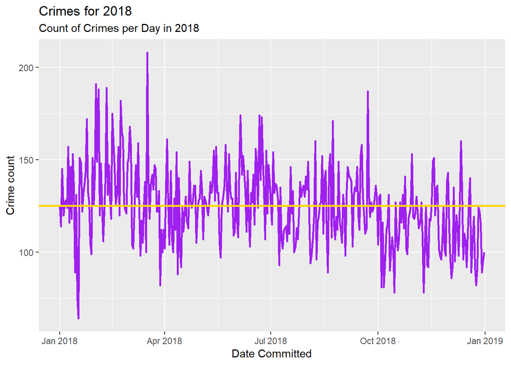

# Crime Rates Per District

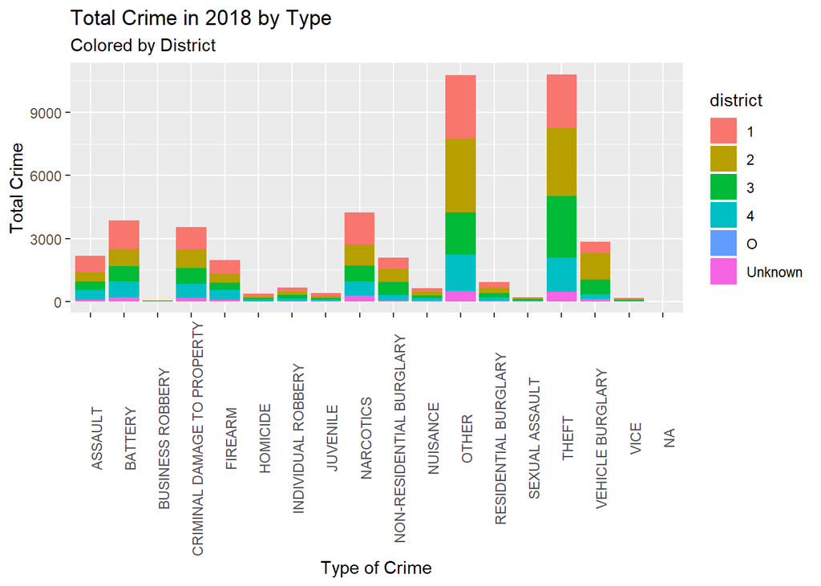

# Opponent’s Effect on Crime Rates

As detailed in the graph below we see the count of crimes committed by the opponent LSU was facing at the time with a color application for the outcome of that game. What we can derive from this is opponents have little effect on the amount of crimes committed in a given day, with the exception of the peak crime date for the Louisiana Tech game, which is to be expected when you put Louisiana up against Louisiana.

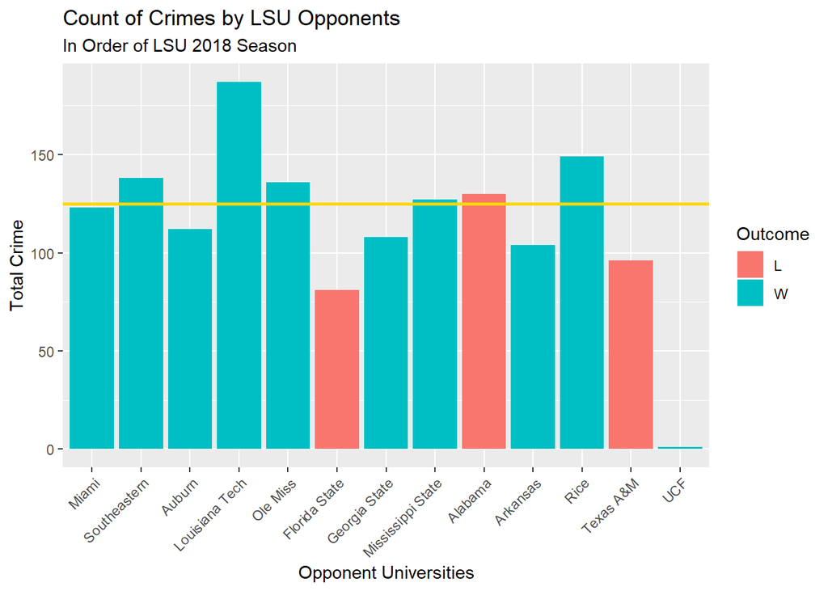

# Internal Variables that might affect Game Outcome

Looking further into what causes the previous factors mentioned to influence crime in Baton Rouge, the next analysis point covers how Game Attendance affect the amount of points LSU scores thereby affecting their probability of winning. As you can see in the graph listed below, losses usually occur with larger audiences, with points scored having little effect on the outcome of the event. Relying on common sense mostly, one can estimate that chances are the losses are linked more toward level of difficulty of the opponent, which usually leads to higher turn out of fans.

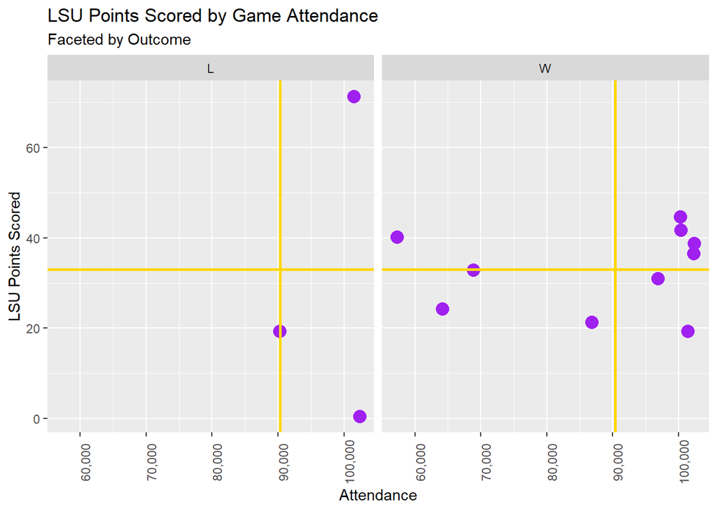

# The True LSU Impact

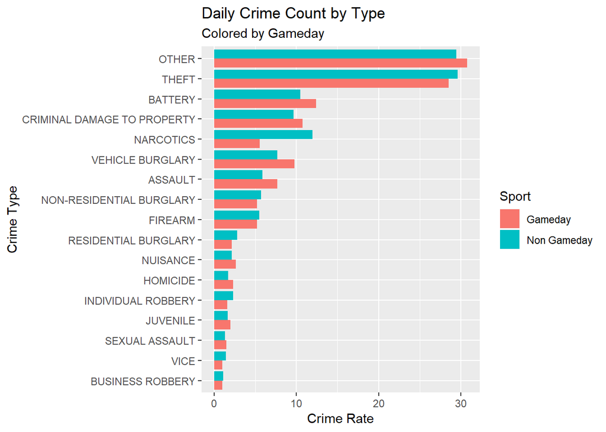

# Conclusion

Through the analysis we have found the answer to our original reasearch question is yes, that LSU events do have an impact on crime rates in the Baton Rouge area. However, not in the original way we imagined, so if we can find a way to tighten our law enforcement on the specific areas of Assault, Battery, and Vehicle Burglary, then we are on our way to making every gameday a win.